# Figure S11 (B, D) – VGLUT1 / VGLUT2 positive-area fraction vs gestational age

Fraction of the cerebellar molecular-layer ROI occupied by VGLUT1+ (B) and VGLUT2+ (D) signal

2026-09-03 10:54:23

# Overview

Immunofluorescence quantification in the cerebellar molecular layer (ML): the **fraction of the ML ROI occupied by VGLUT+ signal**, per subject, vs gestational age at birth. 8 post-mortem cerebella (7 preterm, 1 term). Panels **A/C** (confocal images) are microscopy assets and are not generated here.

- **B** — VGLUT1+ area / total ML area (`Total_Cluster_Area / Cell_Area_um2`, subject-mean of 5 images).
- **D** — VGLUT2+ area / total ML area (`vglut2_pos_area_um2 / area_um2`, whole-ML row, subject-mean).

# Panel B – VGLUT1+ area / total ML area

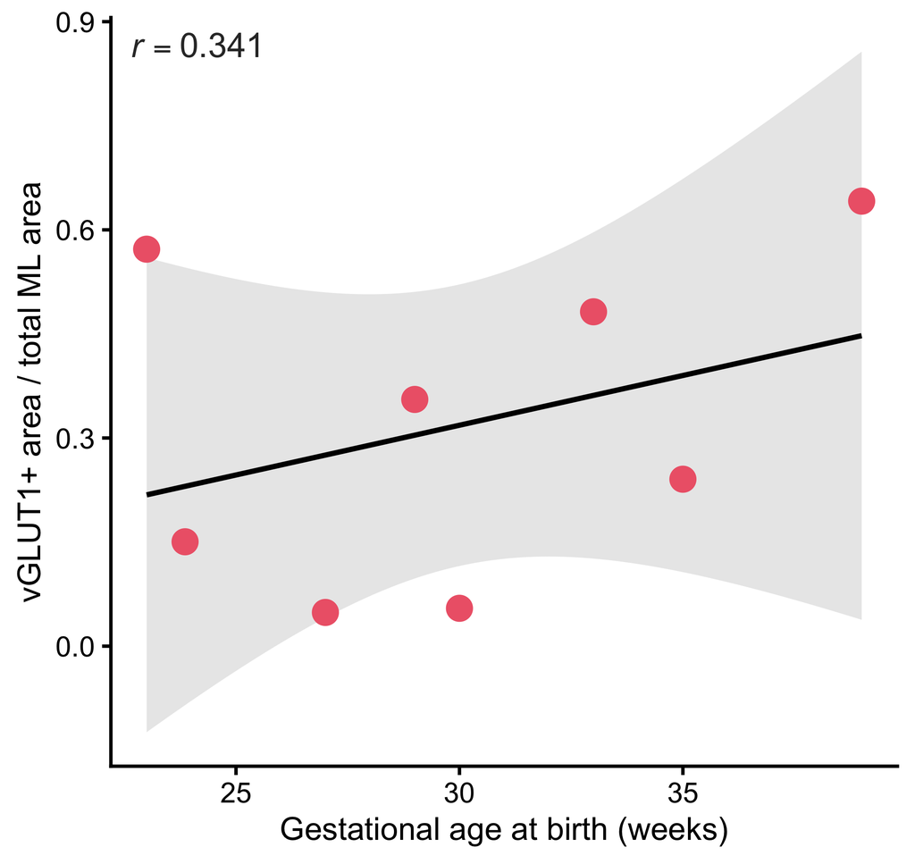

```r
b <- read_excel(find_data("Data_S5_InSitu_Validation.xlsx"), sheet = "VGLUT1_Image_Level") %>%
 mutate(Subject_ID = as.character(Subject_ID),
 pos_area_frac = Total_Cluster_Area / Cell_Area_um2) %>%
 group_by(Subject_ID, GA_weeks) %>%
 summarise(pos_area_frac = mean(pos_area_frac), .groups = "drop") %>%
 rename(GA = GA_weeks)
ctB <- cor.test(b$GA, b$pos_area_frac)

pB <- ggplot(b, aes(GA, pos_area_frac)) +
 geom_smooth(method = "lm", se = TRUE, colour = "black", fill = "grey70", alpha = 0.3, linewidth = 0.7) +
 geom_point(colour = VGLUT1_COL, size = 3) +
 annotate("text", parse = TRUE, x = -Inf, y = Inf, hjust = -0.15, vjust = 1.6,
 label = rlab(ctB$estimate), size = 3.4, colour = "grey20") +
 labs(x = "Gestational age at birth (weeks)", y = "vGLUT1+ area / total ML area") +
 theme_classic(base_size = 10) +
 theme(axis.title = element_text(size = 9), axis.text = element_text(size = 8))
print(pB)
```

```r
ggsave("Figure_S11B_VGLUT1_areafrac.pdf", pB, width = 3.6, height = 3.4, device = cairo_pdf, bg = "white")
cat(sprintf("VGLUT1: n=%d r=%.3f P=%.3f\n", nrow(b), ctB$estimate, ctB$p.value))
```

```
## VGLUT1: n=8 r=0.341 P=0.408
```

# Panel D – VGLUT2+ area / total ML area

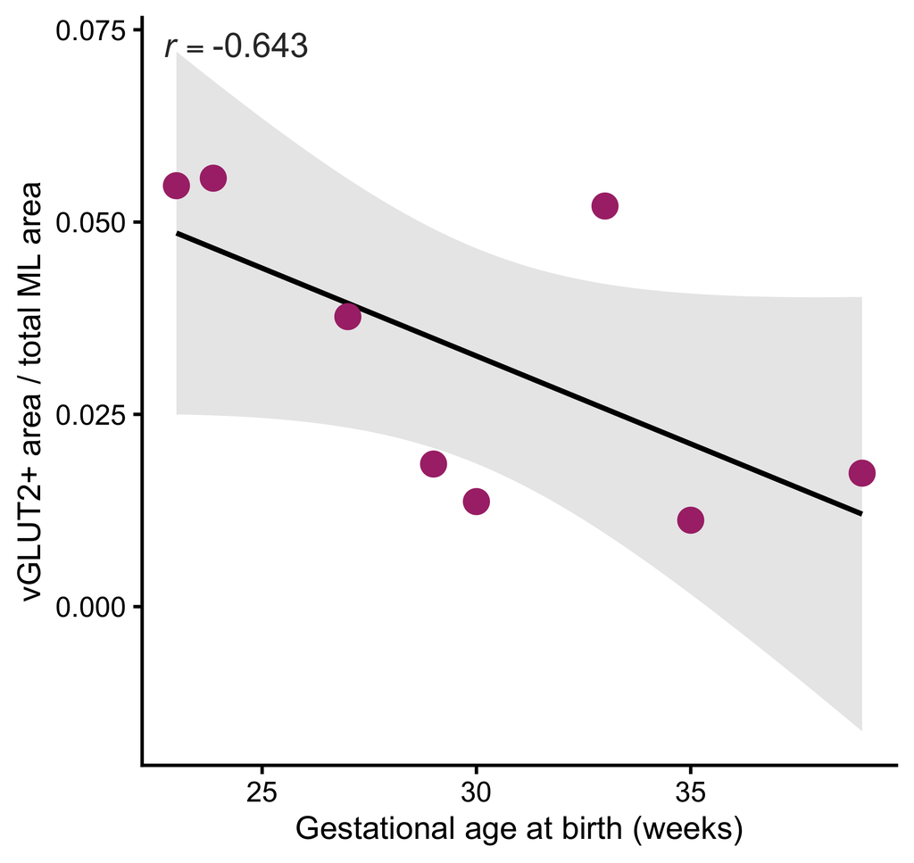

```r
img <- read_excel(find_data("Data_S5_InSitu_Validation.xlsx"), sheet = "VGLUT2_Image_Level") %>%
 mutate(Study_ID = as.character(Subject_ID)) %>%
 filter(region == "ML") %>%
 mutate(pos_area_frac = vglut2_pos_area_um2 / area_um2)

cohort <- read_excel(find_data("Data_S2_Postmortem_Histology.xlsx"), sheet = "Postmortem_Cohort") %>%
 transmute(Study_ID = as.character(Paper_ID),
 Group = factor(Group, levels = c("Preterm", "Term")), GA = as.numeric(GA_wk))

d <- img %>% left_join(cohort, by = "Study_ID") %>%
 filter(Group == "Preterm" | Study_ID == "Term 2") %>%
 mutate(failed = mean_punctum_um2 > 100 | pct_positive_area > 90 | n_puncta < 10) %>%
 filter(!failed) %>%
 group_by(Study_ID, GA) %>%
 summarise(pos_area_frac = mean(pos_area_frac), .groups = "drop")
ctD <- cor.test(d$GA, d$pos_area_frac)

pD <- ggplot(d, aes(GA, pos_area_frac)) +
 geom_smooth(method = "lm", se = TRUE, colour = "black", fill = "grey70", alpha = 0.3, linewidth = 0.7) +
 geom_point(colour = VGLUT2_COL, size = 3) +
 annotate("text", parse = TRUE, x = -Inf, y = Inf, hjust = -0.15, vjust = 1.6,
 label = rlab(ctD$estimate), size = 3.4, colour = "grey20") +
 labs(x = "Gestational age at birth (weeks)", y = "vGLUT2+ area / total ML area") +
 theme_classic(base_size = 10) +
 theme(axis.title = element_text(size = 9), axis.text = element_text(size = 8))
print(pD)
```

```r
ggsave("Figure_S11D_VGLUT2_areafrac.pdf", pD, width = 3.6, height = 3.4, device = cairo_pdf, bg = "white")
cat(sprintf("VGLUT2: n=%d r=%.3f P=%.3f\n", nrow(d), ctD$estimate, ctD$p.value))
```

```
## VGLUT2: n=8 r=-0.643 P=0.086
```

# Statistics

VGLUT+ area / total ML area vs GA (subject-level, n = 8)

| Panel | n | Pearson r | 95% CI | P |
| --- | --- | --- | --- | --- |
| B VGLUT1 | 8 | 0.341 | [-0.478, 0.843] | 0.408 |
| D VGLUT2 | 8 | -0.643 | [-0.927, 0.113] | 0.086 |

# Provenance & data

- **B** source: VGLUT1 image-level quantification; data `Data_S5_InSitu_Validation.xlsx` sheet `VGLUT1_Image_Level`.
- **D** source: VGLUT2 per-image quantification; data = `Data_S5_InSitu_Validation.xlsx` sheet `VGLUT2_Image_Level` (per-image whole-ML rows) linked to the postmortem cohort key (`Data_S2_Postmortem_Histology.xlsx`, sheet `Postmortem_Cohort`); whole-ML QC + single-term (Term 2) selection.
- **Deck restyle:** r-only annotation (no title/P); VGLUT2 recoloured to **magenta #AA3377** (source used blue #4477AA) to match the deck’s VGLUT2 channel; VGLUT1 red #EE6677.